# Data-606-Lab 5A - Sampling Distributions

## Exercise 1

Describe the distribution of responses in this sample. How does it compare to the distribution of responses in the population. Hint: Although the sample_n function takes a random sample of observations (i.e. rows) from the dataset, you can still refer to the variables in the dataset with the same names. Code you presented earlier for visualizing and summarizing the population data will still be useful for the sample, however be careful to not label your proportion p since you’re now calculating a sample statistic, not a population parameters. You can customize the label of the statistics to indicate that it comes from the sample. Insert your answer here

**Answer:**

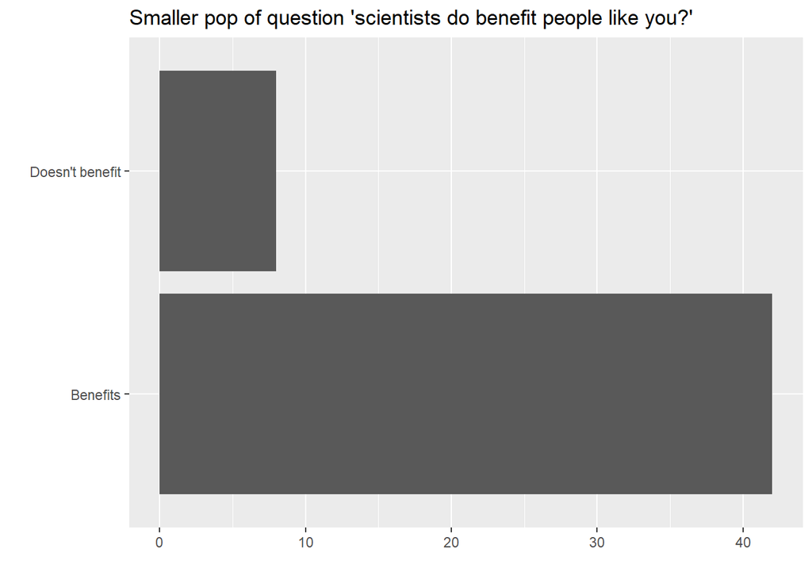

```r
ggplot(samp1, aes(x=scientist_work))+
  geom_bar() +
  labs(
    x = "", y = "",
    title = "Smaller pop of question 'scientists do benefit people like you?'"
  ) +
  coord_flip()
```

```r
samp1 |>
  count(scientist_work) |>
  mutate(samp1s = n/sum(n))
```

```
## # A tibble: 2 × 3
##   scientist_work      n samp1s
##   <chr>           <int>  <dbl>
## 1 Benefits           42   0.84
## 2 Doesn't benefit     8   0.16
```

In my sample of 50 people, 42 (84%) believe that scientists’ work benefits them, while 8 (16%) believe it does not. Compared with the population proportions of 80% and 20%, respectively, my sample has a slightly higher percentage of people who believe that scientists’ work benefits them and a lower percentage of those who do not. This difference is due to random sampling variability.

If you’re interested in estimating the proportion of all people who do not believe that the work scientists do benefits them, but you do not have access to the population data, your best single guess is the sample mean.

```r
samp1 %>%
  count(scientist_work) %>%
  mutate(p_hat = n /sum(n))
```

```
## # A tibble: 2 × 3
##   scientist_work      n p_hat
##   <chr>           <int> <dbl>
## 1 Benefits           42  0.84
## 2 Doesn't benefit     8  0.16
```

## Exercise 2

Would you expect the sample proportion to match the sample proportion of another student’s sample? Why, or why not? If the answer is no, would you expect the proportions to be somewhat different or very different? Ask a student team to confirm your answer.

**Answer:**

No I do not expect my sample proportion to be an exact match the sample proportion of another student’s sample simply because it is a random sample, and I do not know the value of the seed that they set prior to running their test(s). I also expect the proportions to be somewhat different, but still within acceptable limits.

## Exercise 3

Take a second sample, also of size 50, and call it samp2. How does the sample proportion of samp2 compare with that of samp1? Suppose we took two more samples, one of size 100 and one of size 1000. Which would you think would provide a more accurate estimate of the population proportion? Insert your answer here**

**Answer:**

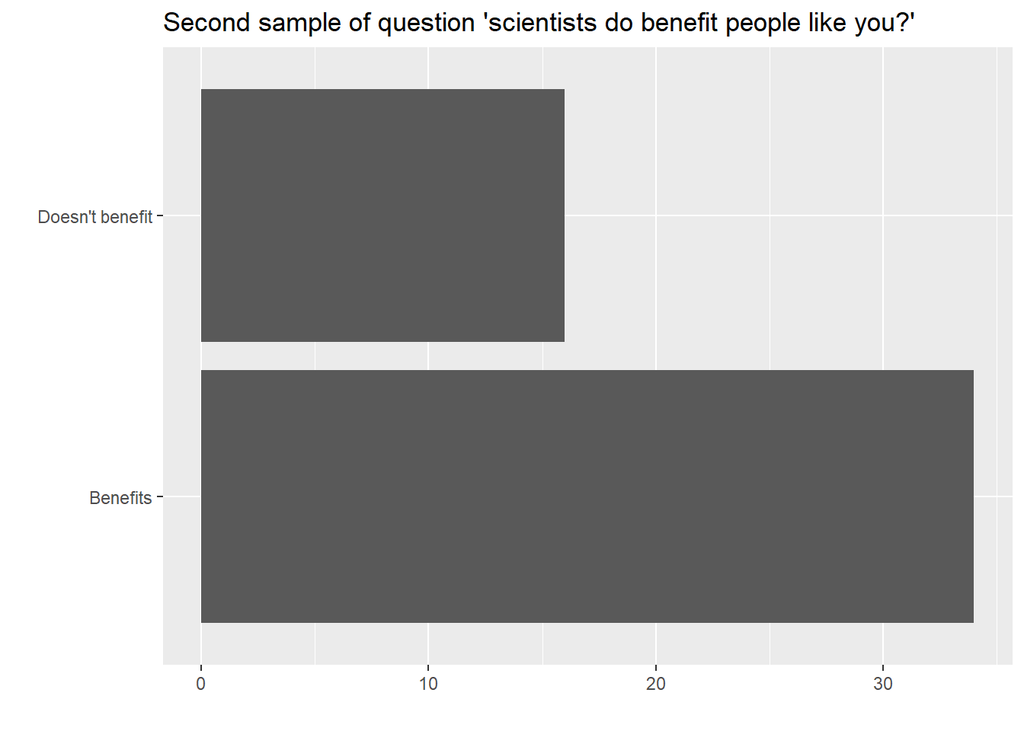

```r
samp2 <- global_monitor %>%
  sample_n(50)
ggplot(samp2, aes(x=scientist_work))+
  geom_bar() +
  labs(
    x = "", y = "",
    title = "Second sample of question 'scientists do benefit people like you?'"
  ) +
  coord_flip()
```

```r
samp2 |>
  count(scientist_work) |>
  mutate(samp2s = n/sum(n))
```

```
## # A tibble: 2 × 3
##   scientist_work      n samp2s
##   <chr>           <int>  <dbl>
## 1 Benefits           34   0.68
## 2 Doesn't benefit    16   0.32
```

In the second sample of 50 people, 68% believe that scientists’ work benefits them, while 32% believe that it does not. These proportions differ from those in the first sample because each random sample may produce different results. Generally, a larger sample size, such as 100 or 1,000, provides a more accurate estimate of the population proportion because the sampling variability decreases as the sample size increases.

Not surprisingly, every time you take another random sample, you might get a different sample proportion. It’s useful to get a sense of just how much variability you should expect when estimating the population mean this way. The distribution of sample proportions, called the sampling distribution (of the proportion), can help you understand this variability. In this lab, because you have access to the population, you can build up the sampling distribution for the sample proportion by repeating the above steps many times. Here, we use R to take 15,000 different samples of size 50 from the population, calculate the proportion of responses in each sample, filter for only the Doesn’t benefit responses, and store each result in a vector called sample_props50. Note that we specify that replace = TRUE since sampling distributions are constructed by sampling with replacement.

```r
sample_props50 <- global_monitor %>%
                    rep_sample_n(size = 50, reps = 15000, replace = TRUE) %>%
                    count(scientist_work) %>%
                    mutate(p_hat = n /sum(n)) %>%
                    filter(scientist_work == "Doesn't benefit")
```

And we can visualize the distribution of these proportions with a histogram.

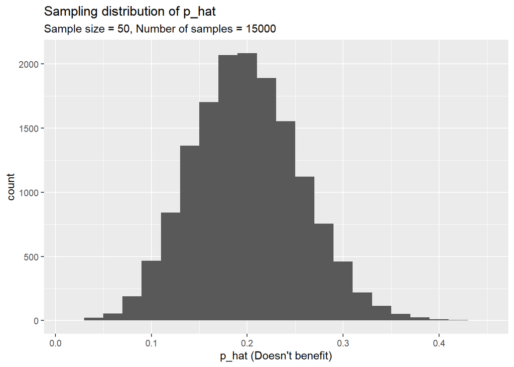

```r
ggplot(data = sample_props50, aes(x = p_hat)) +
  geom_histogram(binwidth = 0.02) +
  labs(
    x = "p_hat (Doesn't benefit)",
    title = "Sampling distribution of p_hat",
    subtitle = "Sample size = 50, Number of samples = 15000"
  )
```

Next, you will review how this set of code works.

## Exercise 4

How many elements are there in sample_props50? Describe the sampling distribution, and be sure to specifically note its center. Make sure to include a plot of the distribution in your answer.

**Answer:**

The sampling distribution contains approximately 15,000 observations, generated from 15,000 random samples of size 50. The distribution is approximately bell-shaped and symmetric, with its center around 0.20 (20%), which represents the true population proportion of people who believe that scientists’ work does not benefit them.

## Interlude: Sampling distributions

The idea behind the rep_sample_n function is repetition. Earlier, you took a single sample of size n (50) from the population of all people in the population. With this new function, you can repeat this sampling procedure rep times in order to build a distribution of a series of sample statistics, which is called the sampling distribution.

Note that in practice one rarely gets to build true sampling distributions, because one rarely has access to data from the entire population.

Without the rep_sample_n function, this would be painful. We would have to manually run the following code 15,000 times

```r
global_monitor %>%
  sample_n(size = 50, replace = TRUE) %>%
  count(scientist_work) %>%
  mutate(p_hat = n /sum(n)) %>%
  filter(scientist_work == "Doesn't benefit")
```

```
## # A tibble: 1 × 3
##   scientist_work      n p_hat
##   <chr>           <int> <dbl>
## 1 Doesn't benefit     7  0.14
```

as well as store the resulting sample proportions each time in a separate vector.

Note that for each of the 15,000 times we computed a proportion, we did so from a different sample!

## Exercise 5

To make sure you understand how sampling distributions are built, and exactly what the rep_sample_n function does, try modifying the code to create a sampling distribution of 25 sample proportions from samples of size 10, and put them in a data frame named sample_props_small. Print the output. How many observations are there in this object called sample_props_small? What does each observation represent?

**Answer:**

```r
sample_props_small <- global_monitor %>%
                    rep_sample_n(size = 10, reps = 25, replace = TRUE) %>%
                    count(scientist_work) %>%
                    mutate(p_hat = n /sum(n)) %>%
                    filter(scientist_work == "Doesn't benefit")

sample_props_small
```

```
## # A tibble: 21 × 4
## # Groups:   replicate [21]
##    replicate scientist_work      n p_hat
##        <int> <chr>           <int> <dbl>
##  1         1 Doesn't benefit     3   0.3
##  2         2 Doesn't benefit     1   0.1
##  3         3 Doesn't benefit     4   0.4
##  4         4 Doesn't benefit     3   0.3
##  5         5 Doesn't benefit     1   0.1
##  6         6 Doesn't benefit     1   0.1
##  7         7 Doesn't benefit     1   0.1
##  8         8 Doesn't benefit     2   0.2
##  9         9 Doesn't benefit     2   0.2
## 10        10 Doesn't benefit     1   0.1
## # ℹ 11 more rows
```

There are 21 observations in `sample_props_small`. Each observation represents the sample proportion of people who believe that scientists’ work does not benefit them in one random sample of 10 people. Four samples do not appear in the output because they contain no respondents in the “Doesn’t benefit” category, and the filter excludes those samples.

## Sample size and the sampling distribution

Mechanics aside, let’s return to the reason we used the rep_sample_n function: to compute a sampling distribution, specifically, the sampling distribution of the proportions from samples of 50 people.

In the remainder of this section, you will work on getting a sense of the effect that sample size has on your sampling distribution.

## Exercise 6

Use the app below to create sampling distributions of proportions of Doesn’t benefit from samples of size 10, 50, and 100. Use 5,000 simulations. What does each observation in the sampling distribution represent? How does the mean, standard error, and shape of the sampling distribution change as the sample size increases? How (if at all) do these values change if you increase the number of simulations? (You do not need to include plots in your answer.)

**Answer:**

Each observation in the sampling distribution represents the sample proportion of respondents who believe that scientists’ work does not benefit them in one random sample.

Using 5,000 simulations, the reported results were:

- Sample size 10: Mean = 0.23, SE = 0.11.
- Sample size 50: Mean = 0.20, SE = 0.06.
- Sample size 100: Mean = 0.20, SE = 0.04.

As the sample size increases, the mean remains close to the true population proportion of 0.20, while the standard error decreases.

The sampling distribution also becomes more concentrated around the population proportion and approaches a normal distribution.

Increasing the number of simulations makes the simulated sampling distribution smoother and provides more stable estimates of its mean and standard error. However, it does not substantially change the theoretical standard error for a fixed sample size.

## More Practice

So far, you have only focused on estimating the proportion of those you think the work scientists doesn’t benefit them. Now, you’ll try to estimate the proportion of those who think it does.

Note that while you might be able to answer some of these questions using the app, you are expected to write the required code and produce the necessary plots and summary statistics. You are welcome to use the app for exploration.

## Exercise 7

Take a sample of size 15 from the population and calculate the proportion of people in this sample who think the work scientists do enhances their lives. Using this sample, what is your best point estimate of the population proportion of people who think the work scientists do enchances their lives?

**Answer:**

```r
samp7 <- global_monitor %>%
  sample_n(15)

samp7 %>%
  count(scientist_work) %>%
  mutate(sam7 = n/sum(n))
```

```
## # A tibble: 1 × 3
##   scientist_work     n  sam7
##   <chr>          <int> <dbl>
## 1 Benefits          15     1
```

In my random sample of 15 people, all 15 believe that scientists’ work benefits them. Therefore, the sample proportion is 15/15 = 1.00, or 100%. This sample proportion is my best point estimate of the population proportion based on this particular sample. It differs from the true population proportion of 80% because of random sampling variability.

## Exercise 8

Since you have access to the population, simulate the sampling distribution of proportion of those who think the work scientists do enchances their lives for samples of size 15 by taking 2000 samples from the population of size 15 and computing 2000 sample proportions. Store these proportions in as sample_props15. Plot the data, then describe the shape of this sampling distribution. Based on this sampling distribution, what would you guess the true proportion of those who think the work scientists do enchances their lives to be? Finally, calculate and report the population proportion.

**Answer:**

```r
sample_props15 <- global_monitor %>%
                    rep_sample_n(size = 15, reps = 2000, replace = TRUE) %>%
                    count(scientist_work) %>%
                    mutate(p_hat = n /sum(n)) %>%
                    filter(scientist_work == "Benefits")

sample_props15
```

```
## # A tibble: 2,000 × 4
## # Groups:   replicate [2,000]
##    replicate scientist_work     n p_hat
##        <int> <chr>          <int> <dbl>
##  1         1 Benefits          10 0.667
##  2         2 Benefits          15 1
##  3         3 Benefits          11 0.733
##  4         4 Benefits          14 0.933
##  5         5 Benefits          12 0.8
##  6         6 Benefits          10 0.667
##  7         7 Benefits          11 0.733
##  8         8 Benefits          10 0.667
##  9         9 Benefits          14 0.933
## 10        10 Benefits          11 0.733
## # ℹ 1,990 more rows
```

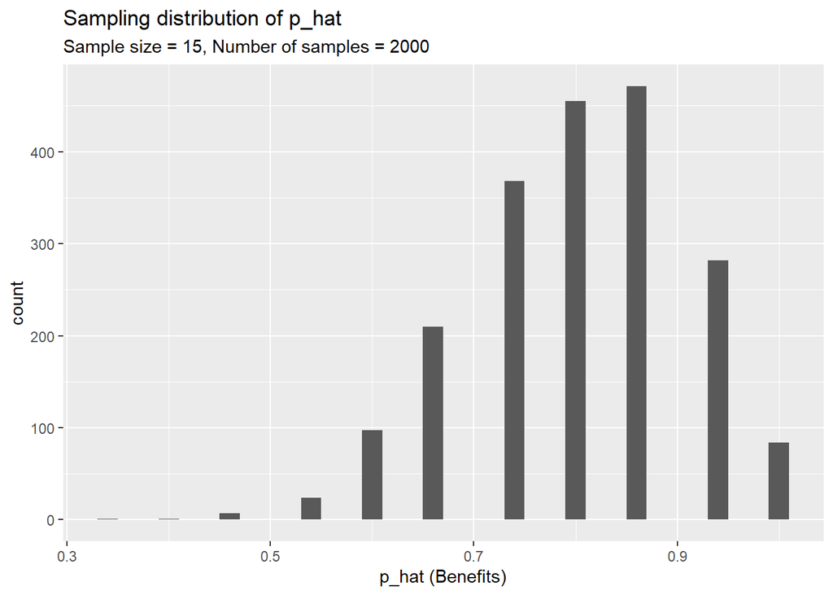

```r
ggplot(data = sample_props15, aes(x=p_hat))+
  geom_histogram(binwidth = .02) +
  labs(
    x = "p_hat (Benefits)",
    title = "Sampling distribution of p_hat",
    subtitle = "Sample size = 15, Number of samples = 2000"
    )
```

```r
mean(sample_props15$p_hat)
```

```
## [1] 0.8021333
```

```r
global_monitor %>%
  count(scientist_work) %>%
  mutate(p = n / sum(n))
```

```
## # A tibble: 2 × 3
##   scientist_work      n     p
##   <chr>           <int> <dbl>
## 1 Benefits        80000   0.8
## 2 Doesn't benefit 20000   0.2
```

The sampling distribution of the sample proportion was created using 2,000 samples, each with a sample size of 15. The mean of the sample proportions was 0.8021, or approximately 80.21%. The distribution is somewhat left-skewed because the sample size is relatively small. The true population proportion of scientists who benefit from the program is 0.80, or 80%. The mean of the simulated sample proportions is close to the true population proportion.

## Exercise 9

Change your sample size from 15 to 150, then compute the sampling distribution using the same method as above, and store these proportions in a new object called sample_props150. Describe the shape of this sampling distribution and compare it to the sampling distribution for a sample size of 15. Based on this sampling distribution, what would you guess to be the true proportion of those who think the work scientists do enchances their lives?

**Answer:**

```r
sample_props150 <- global_monitor %>%
                    rep_sample_n(size = 150, reps = 2000, replace = TRUE) %>%
                    count(scientist_work) %>%
                    mutate(p_hat = n /sum(n)) %>%
                    filter(scientist_work == "Benefits")

sample_props150
```

```
## # A tibble: 2,000 × 4
## # Groups:   replicate [2,000]
##    replicate scientist_work     n p_hat
##        <int> <chr>          <int> <dbl>
##  1         1 Benefits         126 0.84
##  2         2 Benefits         120 0.8
##  3         3 Benefits         118 0.787
##  4         4 Benefits         117 0.78
##  5         5 Benefits         122 0.813
##  6         6 Benefits         114 0.76
##  7         7 Benefits         110 0.733
##  8         8 Benefits         123 0.82
##  9         9 Benefits         123 0.82
## 10        10 Benefits         122 0.813
## # ℹ 1,990 more rows
```

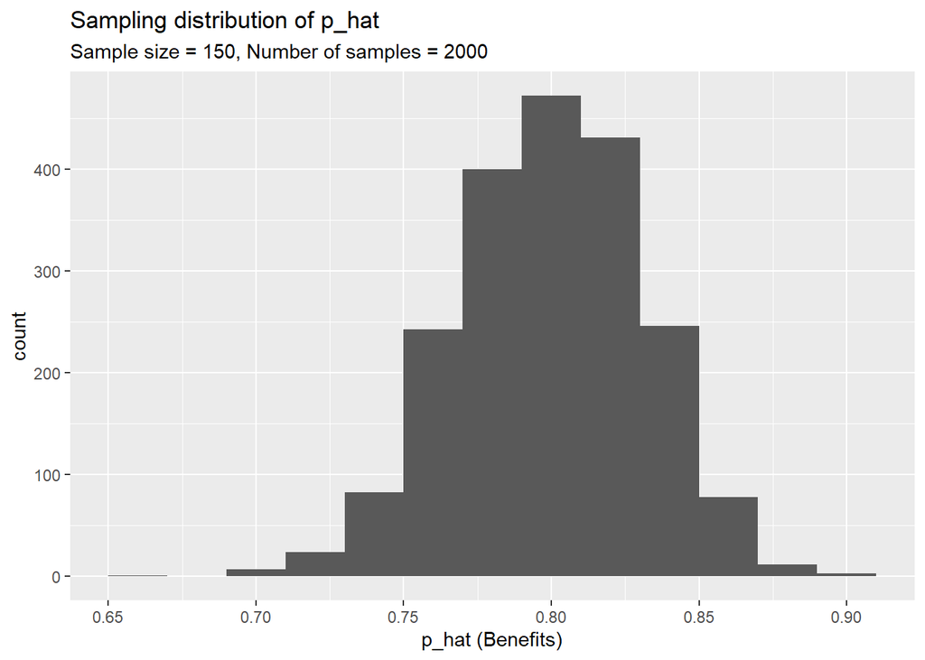

```r
ggplot(data = sample_props150, aes(x=p_hat))+
  geom_histogram(binwidth = .02) +
  labs(
    x = "p_hat (Benefits)",
    title = "Sampling distribution of p_hat",
    subtitle = "Sample size = 150, Number of samples = 2000"
  )
```

```r
mean(sample_props150$p_hat)
```

```
## [1] 0.7997133
```

The sampling distribution was generated from 2,000 random samples, each containing 150 observations. Its mean is approximately 0.7997 (79.97%). Compared with the sampling distribution for a sample size of 15, the distribution for a sample size of 150 has a smaller spread and is more nearly symmetric and bell-shaped. The larger sample size reduces sampling variability, and the estimated population proportion remains close to the true value of 80%.

## Exercise 10

Of the sampling distributions from 2 and 3, which has a smaller spread? If you’re concerned with making estimates that are more often close to the true value, would you prefer a sampling distribution with a large or small spread?

**Answer:**

The sampling distribution based on samples of size 150 has a smaller spread than the sampling distribution based on samples of size 15.

I would prefer a sampling distribution with a smaller spread because its sample proportions are more likely to be close to the true population proportion.

Therefore, using a larger sample size generally provides more precise estimates of the population proportion.